# Smad2 vs Smad3 Differential Binding Analysis after TGF-beta Treatment

### 2.1.3 Looking at the percentage of promoter-proximal peaks

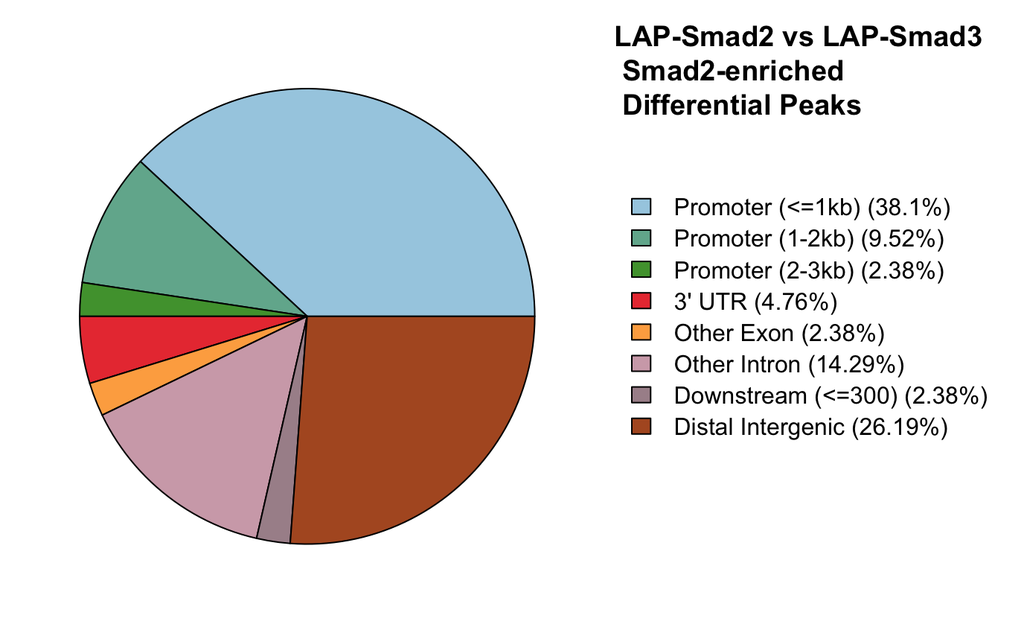

```r
plotAnnoPie(ap_ls2_vs_ls3_smad2enriched)
title(main = "LAP-Smad2 vs LAP-Smad3\n Smad2-enriched\n Differential Peaks", line = -4, adj = 0)
```

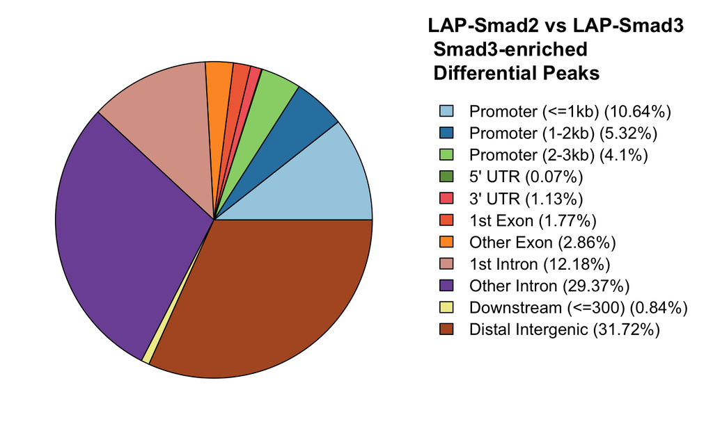

```r
plotAnnoPie(ap_ls2_vs_ls3_smad3enriched)
title(main = "LAP-Smad2 vs LAP-Smad3\n Smad3-enriched\n Differential Peaks", line = -4, adj = 0)
```

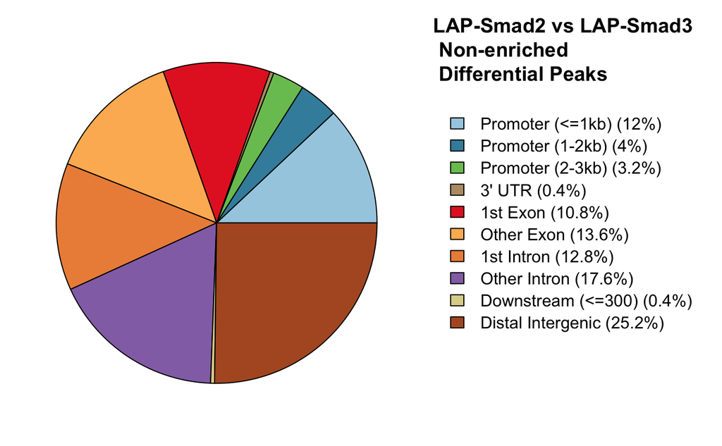

```r
plotAnnoPie(ap_ls2_vs_ls3_bothenriched)
title(main = "LAP-Smad2 vs LAP-Smad3\n Non-enriched\n Differential Peaks", line = -4, adj = 0)
```

### 2.1.4 Creating tibbles from peak annotation data

```r
df_ls2_vs_ls3_smad2enriched <- AnnotationDbi::as.data.frame(ap_ls2_vs_ls3_smad2enriched) %>% as_tibble() %>%
  dplyr::select(seqnames, start, end, width, annotation, GENENAME, log10_LR, SYMBOL, geneId, ENSEMBL, everything())

df_ls2_vs_ls3_smad3enriched <- AnnotationDbi::as.data.frame(ap_ls2_vs_ls3_smad3enriched) %>% as_tibble() %>%
  dplyr::select(seqnames, start, end, width, annotation, GENENAME, log10_LR, SYMBOL, geneId, ENSEMBL, everything())

df_ls2_vs_ls3_bothenriched <- AnnotationDbi::as.data.frame(ap_ls2_vs_ls3_bothenriched) %>% as_tibble() %>%
  dplyr::select(seqnames, start, end, width, annotation, GENENAME, log10_LR, SYMBOL, geneId, ENSEMBL, everything())
```

A peek at the structure of the tibbles:

```r
colnames(df_ls2_vs_ls3_smad2enriched)
```

```
 [1] "seqnames"      "start"         "end"           "width"         "annotation"
 [6] "GENENAME"      "log10_LR"      "SYMBOL"        "geneId"        "ENSEMBL"
[11] "strand"        "geneChr"       "geneStart"     "geneEnd"       "geneLength"
[16] "geneStrand"    "transcriptId"  "distanceToTSS"
```

```r
df_ls2_vs_ls3_smad2enriched
```

| seqnames | start | end | width | annotation | GENENAME | log10_LR | SYMBOL | geneId | ENSEMBL | strand | geneChr | geneStart | geneEnd | geneLength | geneStrand | transcriptId | distanceToTSS |
| --- | --- | --- | --- | --- | --- | --- | --- | --- | --- | --- | --- | --- | --- | --- | --- | --- | --- |
| chr1 | 155189265 | 155189637 | 373 | Promoter (<=1kb) | mucin 1, cell surface associated | 22.76117 | MUC1 | 4582 | ENSG00000185499 | * | 1 | 155185827 | 155188351 | 2525 | 2 | ENST00000462317.5 | -914 |
| chr1 | 155189935 | 155190229 | 295 | Promoter (1-2kb) | mucin 1, cell surface associated | 21.54683 | MUC1 | 4582 | ENSG00000185499 | * | 1 | 155185827 | 155188351 | 2525 | 2 | ENST00000462317.5 | -1584 |
| chr13 | 49799352 | 49799786 | 435 | Distal Intergenic | karyopherin subunit alpha 3 | 13.82806 | KPNA3 | 3839 | ENSG00000102753 | * | 13 | 49699320 | 49792682 | 93363 | 2 | ENST00000261667.8 | -6670 |
| chr18 | 47810163 | 47828546 | 18384 | 3' UTR | SMAD family member 2 | 52.61839 | SMAD2 | 4087 | ENSG00000175387 | * | 18 | 47868263 | 47886923 | 18661 | 2 | ENST00000587353.5 | 58377 |
| chr18 | 47829012 | 47850071 | 21060 | 3' UTR | SMAD family member 2 | 59.59856 | SMAD2 | 4087 | ENSG00000175387 | * | 18 | 47868263 | 47886923 | 18661 | 2 | ENST00000587353.5 | 36852 |
| chr18 | 47850939 | 47852831 | 1893 | Exon (ENST00000262160.11/4087, exon 7 of 11) | SMAD family member 2 | 69.27863 | SMAD2 | 4087 | ENSG00000175387 | * | 18 | 47868263 | 47886923 | 18661 | 2 | ENST00000587353.5 | 34092 |
| chr18 | 47853849 | 47856830 | 2982 | Intron (ENST00000262160.11/4087, intron 6 of 10) | SMAD family member 2 | 49.65791 | SMAD2 | 4087 | ENSG00000175387 | * | 18 | 47868263 | 47886923 | 18661 | 2 | ENST00000587353.5 | 30093 |
| chr18 | 47857123 | 47889607 | 32485 | Promoter (<=1kb) | SMAD family member 2 | 47.71227 | SMAD2 | 4087 | ENSG00000175387 | * | 18 | 47868263 | 47886923 | 18661 | 2 | ENST00000587353.5 | 0 |
| chr18 | 47889817 | 47927655 | 37839 | Promoter (<=1kb) | SMAD family member 2 | 44.35648 | SMAD2 | 4087 | ENSG00000175387 | * | 18 | 47841225 | 47896811 | 55587 | 2 | ENST00000586040.5 | 0 |
| chr18 | 47927875 | 47947510 | 19636 | Promoter (<=1kb) | SMAD family member 2 | 45.67520 | SMAD2 | 4087 | ENSG00000175387 | * | 18 | 47808957 | 47930659 | 121703 | 2 | ENST00000262160.11 | 0 |

[output cut: 32 more lines]

### 2.1.5 Extracting unique list of genes containing promoter-proximal peaks

For both Smad2 and Smad3 respectively, a list of genes was identified whose promoter-proximal regions contained differentially-bound peaks.

```r
prom_genes_ls2_vs_ls3_smad2enriched <- df_ls2_vs_ls3_smad2enriched %>% filter(str_detect(string = annotation, pattern = "Promoter")) %>%
  dplyr::select(GENENAME, geneId) %>%
  distinct(geneId, .keep_all = TRUE) %>%
  tidyr::drop_na()

prom_genes_ls2_vs_ls3_smad3enriched <-  df_ls2_vs_ls3_smad3enriched %>% filter(str_detect(string = annotation, pattern = "Promoter")) %>%
  dplyr::select(GENENAME, geneId) %>%
  distinct(geneId, .keep_all = TRUE) %>%
  tidyr::drop_na()


prom_genes_ls2_vs_ls3_bothenriched <-  df_ls2_vs_ls3_bothenriched %>% filter(str_detect(string = annotation, pattern = "Promoter")) %>%
  dplyr::select(GENENAME, geneId) %>%
  distinct(geneId, .keep_all = TRUE) %>%
  tidyr::drop_na()
```

#### 2.1.5.1 Genes containing promoter-proximal differentially-bound Smad2 peaks

Very few genes were detected with differentially-bound Smad2 peaks near the promoter.

```r
prom_genes_ls2_vs_ls3_smad2enriched
```

| GENENAME | geneId |
| --- | --- |
| mucin 1, cell surface associated | 4582 |
| SMAD family member 2 | 4087 |
| microRNA 3648-1 | 100500862 |
| RNA, 45S pre-ribosomal N2 | 109864279 |
| RNA, 5.8S ribosomal N4 | 109864274 |
| microRNA 6724-1 | 102465433 |

```r
NA
```

#### 2.1.5.2 Genes containing promoter-proximal differentially enriched Smad3 peaks

On the other hand, numerous genes were detected with differentially-bound Smad3 peaks near the promoter.

```r
prom_genes_ls2_vs_ls3_smad3enriched
```

| GENENAME | geneId |
| --- | --- |
| DEAD/H-box helicase 11 like 1 | 100287102 |
| microRNA 6859-1 | 102466751 |
| family with sequence similarity 138 member A | 645520 |
| uncharacterized LOC729737 | 729737 |
| DEAD/H-box helicase 11 pseudogene | 102725121 |
| uncharacterized LOC100132287 | 100132287 |
| uncharacterized LOC100288175 | 100288175 |
| chromosome 1 open reading frame 159 | 54991 |
| tubulin tyrosine ligase like 10 | 254173 |
| ubiquitin conjugating enzyme E2 J2 | 118424 |

[output cut: 990 more lines]

#### 2.1.5.3 Genes with promoter-proximal peaks which are not significantly differentially enriched for either Smad2 or Smad3 binding

The following were the genes whose promoters contained regions were not differentially-bound by either Smad2 or Smad2.

```r
prom_genes_ls2_vs_ls3_bothenriched
```

| GENENAME | geneId |
| --- | --- |
| CROCC pseudogene 2 | 84809 |
| tectorin alpha | 7007 |
| BRF1 RNA polymerase III transcription initiation factor subunit | 2972 |
| DEAD/H-box helicase 11 like 9 | 100288486 |
| RNA, U2 small nuclear 1 | 6066 |
| microRNA 8078 | 102466878 |
| uncharacterized LOC100134317 | 100134317 |
| uncharacterized LOC284412 | 284412 |
| solute carrier family 17 member 9 | 63910 |
| long intergenic non-protein coding RNA 1667 | 441058 |

[output cut: 18 more lines]

### 2.1.6 Getting a list of “ambiguous” genes by performing set operations on LAP-Smad2 vs LAP-Smad3 gene lists

“Ambiguous” genes are those genes which cannot be said to have promoters containing exclusively Smad2- or exclusively Smad3-associated differentially enriched peaks. These genes primarily belong to three groups:

1. Genes common to both the Smad2-differentially enriched peak set and the non-differentially expressed peak set
2. Genes common to both the Smad3-differentially enriched peak set and the non-differentially expressed peak set
3. Genes common to both the Smad2-differentially enriched peak set and the Smad3-differentially enriched peak set

In the case of number 1, such genes have promoters with two different kind of segments: segments containing Smad2-differentially enriched peaks, and segments containing peaks which are not particularly differentially expressed. Similarly, for number 2, these genes have promoters with segments containing Smad3-differentially enriched peaks, and segments containing peaks which are not particularly differentially expressed. In the case of number 3, these genes have promoters where certain peaks are differentially-enriched for Smad2, while other peaks are differentially-enriched for Smad3. Since we are attempting to evaluate differences between the Smad2 and Smad3 axes , we considered it more appropriate to focus on genes whose promoters contain either exclusively Smad2 differentially-enriched peaks or exclusively Smad3 differentially-enriched peaks, in order to better appreciate the differences between the gene sets regulated by both these axes in a coarse-grained manner. Hence, it was deemed appropriate to remove “ambiguous” genes from the list of genes associated exclusively with either Smad2 or Smad3 differentially-enriched peaks, before subjecting that respective gene list to GO term enrichement analysis.

The complete list of “ambiguous” genes can be obtained by taking the union of the three sets of genes described in numbers 1, 2 and 3.

Firstly, we took a look at the list of genes common to both the Smad2-differentially enriched peak set and the Smad3-differentially enriched peak set. There were only four.

```r
intersect(prom_genes_ls2_vs_ls3_smad2enriched$GENENAME, prom_genes_ls2_vs_ls3_smad3enriched$GENENAME) %>% # finding common peaks between LAP-Smad2 and LAP-Smad3
  tibble::enframe(name = "No.", value = "Promoter-proximal peak annotations") %>%
  tidyr::drop_na()
```

| No. | Promoter-proximal peak annotations |
| --- | --- |
| 1 | microRNA 3648-1 |
| 2 | RNA, 45S pre-ribosomal N2 |
| 3 | RNA, 5.8S ribosomal N4 |
| 4 | microRNA 6724-1 |

Then, we took a look at the list of genes common to both the Smad2-differentially enriched peak set and the non-differentially expressed peak set. None existed.

```r
intersect(prom_genes_ls2_vs_ls3_smad2enriched$GENENAME, prom_genes_ls2_vs_ls3_bothenriched$GENENAME) %>%
  tibble::enframe(name = "No.", value = "Promoter-proximal peak annotations") %>%
  tidyr::drop_na()
```

| No. | Promoter-proximal peak annotations |
| --- | --- |

```r
NA
```

Then, we took a look at genes common to both the Smad3-differentially enriched peak set and the non-differentially expressed peak set. There were 18 such genes.

```r
intersect(prom_genes_ls2_vs_ls3_smad3enriched$GENENAME, prom_genes_ls2_vs_ls3_bothenriched$GENENAME) %>%
  tibble::enframe(name = "No.", value = "Promoter-proximal peak annotations") %>%
  tidyr::drop_na()
```

| No. | Promoter-proximal peak annotations |
| --- | --- |
| 1 | CROCC pseudogene 2 |
| 2 | BRF1 RNA polymerase III transcription initiation factor subunit |
| 3 | DEAD/H-box helicase 11 like 9 |
| 4 | RNA, U2 small nuclear 1 |
| 5 | microRNA 8078 |
| 6 | uncharacterized LOC100134317 |
| 7 | uncharacterized LOC284412 |
| 8 | long intergenic non-protein coding RNA 1667 |
| 9 | poly(rC) binding protein 3 |
| 10 | small nucleolar RNA host gene 27 |

[output cut: 8 more lines]

Finally, we derived the list of ambigous genes by taking the union of the three gene lists above.

```r
dplyr::union(intersect(prom_genes_ls2_vs_ls3_smad2enriched$GENENAME, prom_genes_ls2_vs_ls3_bothenriched$GENENAME),
      intersect(prom_genes_ls2_vs_ls3_smad3enriched$GENENAME,prom_genes_ls2_vs_ls3_bothenriched$GENENAME)) %>%
  dplyr::union(., intersect(prom_genes_ls2_vs_ls3_smad2enriched$GENENAME, prom_genes_ls2_vs_ls3_smad3enriched$GENENAME)) %>%
  tibble::enframe(name = "No.", value = "'Ambiguous' genes") %>%
  tidyr::drop_na()
```

| No. | 'Ambiguous' genes |
| --- | --- |
| 1 | CROCC pseudogene 2 |
| 2 | BRF1 RNA polymerase III transcription initiation factor subunit |
| 3 | DEAD/H-box helicase 11 like 9 |
| 4 | RNA, U2 small nuclear 1 |
| 5 | microRNA 8078 |
| 6 | uncharacterized LOC100134317 |
| 7 | uncharacterized LOC284412 |
| 8 | long intergenic non-protein coding RNA 1667 |
| 9 | poly(rC) binding protein 3 |
| 10 | small nucleolar RNA host gene 27 |

[output cut: 12 more lines]

```r
NA
```

```r
### Assigning 'ambiguous' genes to a variable

ambi_ls2_vs_ls3 <- dplyr::union(intersect(prom_genes_ls2_vs_ls3_smad2enriched$geneId, prom_genes_ls2_vs_ls3_bothenriched$geneId), intersect(prom_genes_ls2_vs_ls3_smad3enriched$geneId, prom_genes_ls2_vs_ls3_bothenriched$geneId)) %>%
  dplyr::union(., intersect(prom_genes_ls2_vs_ls3_smad2enriched$geneId, prom_genes_ls2_vs_ls3_smad3enriched$geneId))
```

To further investigate “ambigouous” genes separately, the following variables from the workspace were saved to an RData object for loading during the investigation.

```r
save( list = c("df_ls2_vs_ls3_bothenriched", "df_ls2_vs_ls3_smad2enriched", "df_ls2_vs_ls3_smad3enriched", "df_ls2_vs_ns3_bothenriched", "df_ls2_vs_ns3_smad2enriched", "df_ls2_vs_ns3_smad3enriched", "ambi_ls2_vs_ls3", "ambi_ls2_vs_ns3"), file = "Gviz_motif.RData")
```

### 2.1.7 GO term enrichment analysis

The “ambiguous” genes were filtered out from the genes with Smad2 or Smad3 differentially-enriched promoter-proximal peaks, and the remaining genes were subjected from GO term enrichment analysis. GO term annotations were limited to those related to biological processes (BP) and were filtered only to those having an adjusted p-value of 0.05. The enriched GO terms were sorted first by adjusted p-values in ascending order, by their count of occurrences in descending order, and by their gene ratio in descending order.

#### 2.1.7.1 GO terms enriched in Smad2-exclusive differentially enriched peaks

**Note**: Since the code for the GO Term analysis takes a long time to process, the objects generated from the running of that code have been saved separately to the file “differential_binding_go_term.RData”. To save time while generating the output for this Rmarkdown notebook, they will be loaded directly from the aforementioned file in the following code chunk, whenever needed. However, the original source code chunks generating the objects themselves are still displayed.

The following is the list of genes that was passed through the function for the GO Term analysis, after filtering out the ambiguous genes.

```r
prom_genes_ls2_vs_ls3_smad2enriched %>% filter(!geneId %in% ambi_ls2_vs_ls3)
```

| GENENAME | geneId |
| --- | --- |
| mucin 1, cell surface associated | 4582 |
| SMAD family member 2 | 4087 |

```r
### Code chunk not evaluated in this instance
ego_prom_genes_ls2_vs_ls3_smad2enriched <- enrichGO(gene = (prom_genes_ls2_vs_ls3_smad2enriched %>% filter(!geneId %in% ambi_ls2_vs_ls3) %>% dplyr::select(geneId) %>% unlist(use.names = FALSE)), org.Hs.eg.db, ont = "BP", pAdjustMethod = "BH", readable = TRUE)
```

The results below can be a little misleading, since the list of enriched GO Terms is derived from a list of genes which is only 2 in number. Hence, the miniscule number of genes (2) forming the denominator, compared to the background set, whose denominator is 18,493, will skew the results of the enrichment analysis. The above enrichment analysis, therefore, would not be deemed accurate.

```r
ego_prom_genes_ls2_vs_ls3_smad2enriched@result %>%
  as_tibble() %>%
  arrange(p.adjust, desc(Count) , desc(GeneRatio))  %>%
  filter(p.adjust < 0.05) %>%
  dplyr::select(Description, p.adjust, GeneRatio, BgRatio, geneID)
```

| Description | p.adjust | GeneRatio | BgRatio | geneID |
| --- | --- | --- | --- | --- |
| foregut morphogenesis | 0.02363413 | 1/2 | 10/18493 | SMAD2 |
| primary miRNA processing | 0.02363413 | 1/2 | 10/18493 | SMAD2 |
| dorsal/ventral axis specification | 0.02363413 | 1/2 | 11/18493 | SMAD2 |
| negative regulation of cell adhesion mediated by integrin | 0.02363413 | 1/2 | 11/18493 | MUC1 |
| SMAD protein complex assembly | 0.02363413 | 1/2 | 13/18493 | SMAD2 |
| regulation of histone H4 acetylation | 0.02363413 | 1/2 | 13/18493 | MUC1 |
| DNA damage response, signal transduction by p53 class mediator resulting in transcription of p21 class mediator | 0.02363413 | 1/2 | 15/18493 | MUC1 |
| lateral mesoderm development | 0.02363413 | 1/2 | 15/18493 | SMAD2 |
| DNA damage response, signal transduction resulting in transcription | 0.02363413 | 1/2 | 16/18493 | MUC1 |
| negative regulation of intrinsic apoptotic signaling pathway in response to DNA damage by p53 class mediator | 0.02363413 | 1/2 | 16/18493 | MUC1 |

[output cut: 200 more lines]

```r
NA
```

#### 2.1.7.2 GO terms enriched in Smad3-exclusive differentially enriched peaks

The following is the list of genes that was passed through the function for the GO Term analysis, after filtering out the ambiguous genes.

```r
prom_genes_ls2_vs_ls3_smad3enriched %>% filter(!geneId %in% ambi_ls2_vs_ls3)
```

| GENENAME | geneId |
| --- | --- |
| DEAD/H-box helicase 11 like 1 | 100287102 |
| microRNA 6859-1 | 102466751 |
| family with sequence similarity 138 member A | 645520 |
| uncharacterized LOC729737 | 729737 |
| DEAD/H-box helicase 11 pseudogene | 102725121 |
| uncharacterized LOC100132287 | 100132287 |
| uncharacterized LOC100288175 | 100288175 |
| chromosome 1 open reading frame 159 | 54991 |
| tubulin tyrosine ligase like 10 | 254173 |
| ubiquitin conjugating enzyme E2 J2 | 118424 |

[output cut: 990 more lines]

```r
NA
```

The results of the Smad3 analysis can be deemed to be somewhat more accurate as compared to the Smad2 analysis, due to the comparatively longer list of non-ambiguous genes (1576).

```r
ego_prom_genes_ls2_vs_ls3_smad3enriched@result %>%
   as_tibble() %>%
   arrange(p.adjust, desc(Count) , desc(GeneRatio))  %>%
   filter(p.adjust < 0.05) %>%
   dplyr::select(Description, p.adjust, GeneRatio, BgRatio, geneID)
```

| Description | p.adjust | GeneRatio | BgRatio | geneID |
| --- | --- | --- | --- | --- |
| positive regulation of GTPase activity | 1.136464e-08 | 79/1576 | 405/18493 | ACAP3/EPHA2/DOCK7/RABGAP1L/DENND1B/SRGAP2/ARHGAP22/AGAP6/AGA…… |
| regulation of GTPase activity | 3.140873e-08 | 87/1576 | 481/18493 | ACAP3/EPHA2/DOCK7/IQGAP3/RABGAP1L/DENND1B/SRGAP2/ARHGAP22/AG…… |
| activation of GTPase activity | 4.248442e-05 | 26/1576 | 91/18493 | EPHA2/DOCK7/RABGAP1L/TBC1D15/GRTP1/NTRK3/PLEKHG4/MTSS1L/SGSM2/TBC1D28/TBC1D3G/TBC1D3H/TBC1D3F/TBC1D3/TBC1D3I/TBC1D3C/TBC1D3D/TBC1D3E/TBC1D8/RANGAP1/ECT2/TBC1D14/TBCK/TBC1D9B/ARHGEF10/TSC1 |
| regulation of small GTPase mediated signal transduction | 1.435311e-03 | 54/1576 | 321/18493 | EPS8L3/SRGAP2/ARHGAP22/MADD/ARAP1/CDON/PLEKHG6/RACGAP1/SRGAP…… |
| regulation of Ras protein signal transduction | 5.190410e-03 | 40/1576 | 222/18493 | EPS8L3/MADD/PLEKHG6/SPRY2/PLEKHG3/ADGRG1/PLEKHG4/ABR/CRK/ITG…… |
| protein autophosphorylation | 4.273967e-02 | 37/1576 | 227/18493 | CLK2/MAP3K21/MYO3A/SIK2/STK24/EIF2S1/CALM1/AKT1/DAPK2/SMG1/M…… |
| regulation of protein binding | 4.273967e-02 | 36/1576 | 217/18493 | PARK7/RPL11/LDLRAP1/DISC1/SORL1/UBASH3B/CDON/DDX11/TMBIM6/BM…… |
| nuclear export | 4.273967e-02 | 33/1576 | 194/18493 | PARK7/SRRM1/LZTS2/NEMF/SRSF5/PKD1/RNPS1/SMG1/NUP93/DDX19B/SMG6/NUP88/EIF5A/SRSF1/UPF1/U2AF2/XPO1/RANBP2/WDR33/RAE1/RANGAP1/SETD2/LSG1/RBM27/SLU7/ATXN1/SRSF3/NUPL2/POM121C/CDK5/TSC1/NXF3/THOC2 |
| regulation of Rho protein signal transduction | 4.273967e-02 | 26/1576 | 136/18493 | EPS8L3/PLEKHG6/PLEKHG3/ADGRG1/PLEKHG4/ABR/ITGA3/VAV1/MYO9B/ARHGEF1/APOE/FARP2/ITSN1/BCR/RAF1/ECT2/TRIO/ARHGEF28/ARHGEF37/PDGFRB/FLOT1/ARHGEF5/ARHGEF10/KANK1/VAV2/MCF2 |
| regulation of posttranscriptional gene silencing | 4.273967e-02 | 19/1576 | 83/18493 | ZMPSTE24/HIST2H3D/HIST2H4B/HIST2H3A/HIST4H4/NCOR2/BMP4/POLR2E/ELAVL1/PPARG/FXR1/POLR2H/PPP3CA/TERT/HIST1H4H/HIST1H4J/HIST1H4K/ESR1/POLR2J |

[output cut: 19 more lines]

```r
NA
```

Regulation of GTPase activity seemed to be a common theme among the enriched GO terms in Smad3-exclusive differentially enriched promoter-proximal peaks.

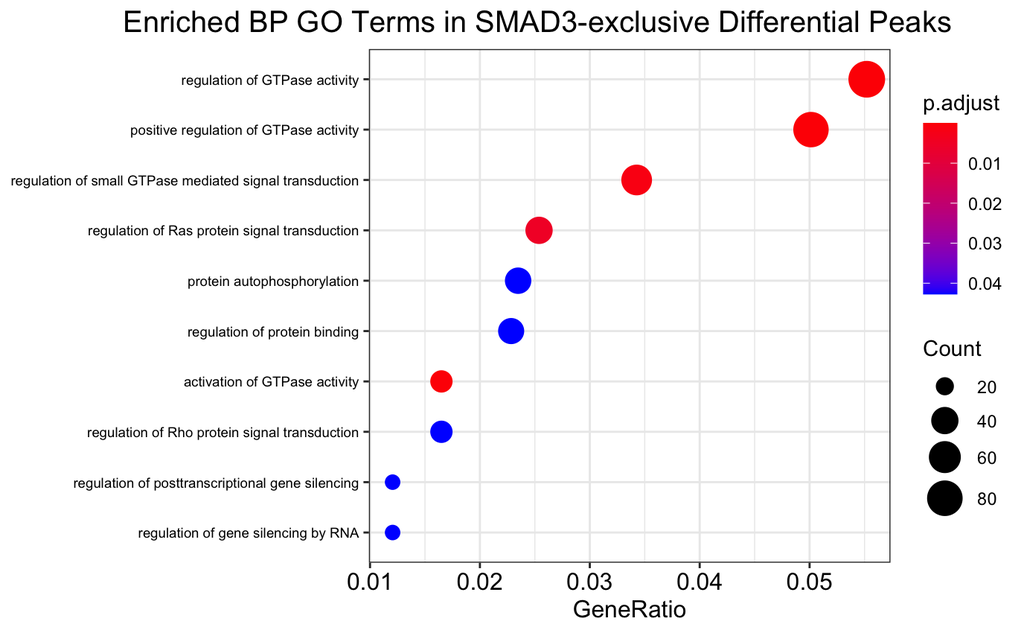

```r
dotplot(ego_prom_genes_ls2_vs_ls3_smad3enriched) +
  ggtitle(label = "Enriched BP GO Terms in SMAD3-exclusive Differential Peaks") +
  theme(plot.title = element_text(hjust = 0.8, size = 15), axis.text.y = element_text(size = 7))
```

## 2.2 LAP-Smad2 vs native-Smad3

### 2.2.1 Creating GRanges objects from bedgraph files

```r
bed_ls2_vs_ns3_smad2enriched <- read_tsv("./treated-diffpeak_results/diff_lap-smad2_vs_native-smad3_c3.0_cond1.bed", skip = 1, col_names = c("chrom", "start", "end", "name", "log10_likelihood_ratio"))
ls2_vs_ns3_smad2enriched <- GRanges(seqnames = bed_ls2_vs_ns3_smad2enriched$chrom, ranges = IRanges(start = bed_ls2_vs_ns3_smad2enriched$start, end = bed_ls2_vs_ns3_smad2enriched$end), log10_LR = bed_ls2_vs_ns3_smad2enriched$log10_likelihood_ratio)

ranges(ls2_vs_ns3_smad2enriched)
```

```
IRanges object with 291 ranges and 0 metadata columns:
            start       end     width
        <integer> <integer> <integer>
    [1]  54561826  54562288       463
    [2] 111607539 111607767       229
    [3] 125117411 125117626       216
    [4] 155188595 155188810       216
    [5] 155189235 155190300      1066
    ...       ...       ...       ...
  [287]  50057309  50057661       353
  [288]  53578758  53578990       233
  [289]  72681936  72682187       252
  [290] 109054324 109054546       223
  [291]  11259630  11259896       267
```

```r
bed_ls2_vs_ns3_smad3enriched <- read_tsv("./treated-diffpeak_results/diff_lap-smad2_vs_native-smad3_c3.0_cond2.bed", skip = 1, col_names = c("chrom", "start", "end", "name", "log10_likelihood_ratio"))
ls2_vs_ns3_smad3enriched <- GRanges(seqnames = bed_ls2_vs_ns3_smad3enriched$chrom, ranges = IRanges(start = bed_ls2_vs_ns3_smad3enriched$start, end = bed_ls2_vs_ns3_smad3enriched$end), log10_LR = bed_ls2_vs_ns3_smad3enriched$log10_likelihood_ratio)

bed_ls2_vs_ns3_bothenriched <- read_tsv("./treated-diffpeak_results/diff_lap-smad2_vs_native-smad3_c3.0_common.bed", skip = 1, col_names = c("chrom", "start", "end", "name", "log10_likelihood_ratio"))
ls2_vs_ns3_bothenriched <- GRanges(seqnames = bed_ls2_vs_ns3_bothenriched$chrom, ranges = IRanges(start = bed_ls2_vs_ns3_bothenriched$start, end = bed_ls2_vs_ns3_bothenriched$end), log10_LR = bed_ls2_vs_ns3_bothenriched$log10_likelihood_ratio)
```

### 2.2.2 Annotating peaks

```r
ap_ls2_vs_ns3_smad2enriched <- annotatePeak(peak = ls2_vs_ns3_smad2enriched, TxDb = TxDb, annoDb = "org.Hs.eg.db")
```

```
>> preparing features information...         2021-01-07 11:46:37
>> identifying nearest features...       2021-01-07 11:46:37
>> calculating distance from peak to TSS...  2021-01-07 11:46:38
>> assigning genomic annotation...       2021-01-07 11:46:38
>> adding gene annotation...             2021-01-07 11:46:42
```

```
>> assigning chromosome lengths          2021-01-07 11:46:42
>> done...                   2021-01-07 11:46:42
```

```r
ap_ls2_vs_ns3_smad3enriched <- annotatePeak(peak = ls2_vs_ns3_smad3enriched, TxDb = TxDb, annoDb = "org.Hs.eg.db")
```

```
>> preparing features information...         2021-01-07 11:46:42
>> identifying nearest features...       2021-01-07 11:46:42
>> calculating distance from peak to TSS...  2021-01-07 11:46:44
>> assigning genomic annotation...       2021-01-07 11:46:44
>> adding gene annotation...             2021-01-07 11:46:48
```

```
>> assigning chromosome lengths          2021-01-07 11:46:48
>> done...                   2021-01-07 11:46:48
```

```r
ap_ls2_vs_ns3_bothenriched <- annotatePeak(peak = ls2_vs_ns3_bothenriched, TxDb = TxDb, annoDb = "org.Hs.eg.db")
```

```
>> preparing features information...         2021-01-07 11:46:48
>> identifying nearest features...       2021-01-07 11:46:48
>> calculating distance from peak to TSS...  2021-01-07 11:46:48
>> assigning genomic annotation...       2021-01-07 11:46:48
>> adding gene annotation...             2021-01-07 11:46:52
```

```
>> assigning chromosome lengths          2021-01-07 11:46:52
>> done...                   2021-01-07 11:46:52
```